# Case 31: Summary of Data Analysis

IC11-2: R1, R2, R5, & R6 — Employees Federal Credit Union

Jake Evans

Cal Poly Pomona

2026-11-10

# Data

## Data Used

- **Data:** `Case31_Data_efcu_JE_cleaned.sav`, the cleaned file from IC10-2-1 (Data Preparation)
- **Participants:** 128 members
- **Coding used in this analysis:**
  - “No opinion” (q7, q8, q37) and “No answer” (q12) were set to missing
  - q7r, q8r, q10r, and q37r are reverse coded so a larger number = a higher rating
  - q13r-q26r: 1 = Unaware, 2 = Aware but Have Not Used, 3 = Aware and Have Used
  - q9_group: statement frequency grouped into too often / about right / not often enough
- **Decision rule:** reject H<sub>0</sub> when *p* < .05

# R1: One-Sample t-test

**R1: Why do people join the Credit Union?**

- `Constructs and roles`: Reasons why people join the Credit Union (descriptive)
- `Operationalization`: q7r (opinion on the rates CU pays on share/savings accounts)
- `Scale`: 1-5 point, Likert-type scale (1 = Very Low … 5 = Very High)
- `Statistics`: Descriptive statistics, followed by one-sample t-test

## Descriptive Statistics

Table 1: Response Frequency of Savings Rate (q7r)

| Savings Rate | n | % |
| --- | --- | --- |
| Very Low | 1 | 0.8 |
| Low | 12 | 10.2 |
| Average | 83 | 70.3 |
| High | 22 | 18.6 |
| Very High | 0 | 0.0 |

Table 2: Descriptive Statistics for Savings Rate (q7r)

| n | mean | sd | median | min | max | skew | kurtosis |
| --- | --- | --- | --- | --- | --- | --- | --- |
| 118 | 3.07 | 0.57 | 3 | 1 | 4 | -0.26 | 1.18 |

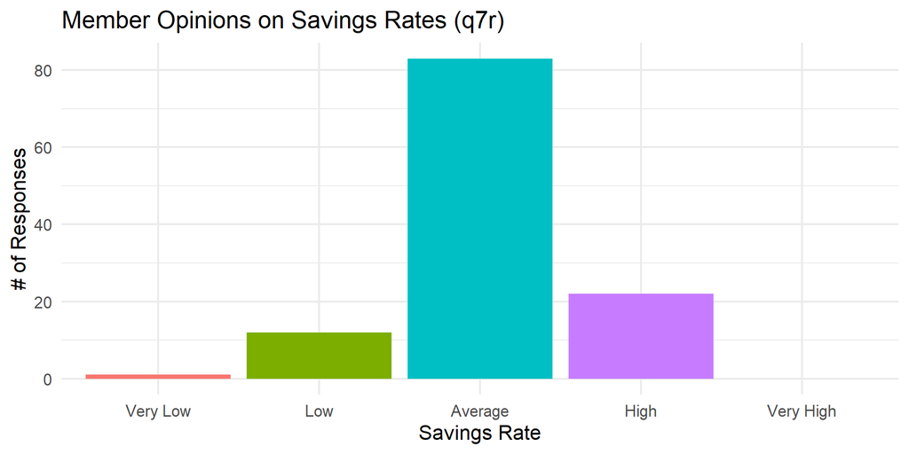

Figure 1: Frequency of Member Opinions on Savings Rates

## One-Sample t-test

- H<sub>0</sub>: μ = 3 (members rate the savings rate as “Average”)
- H<sub>A</sub>: μ ≠ 3

```r
t.test(case31$q7r, mu = 3)
```

```
    One Sample t-test

data:  case31$q7r
t = 1.3016, df = 117, p-value = 0.1956
alternative hypothesis: true mean is not equal to 3
95 percent confidence interval:
 2.964639 3.170954
sample estimates:
mean of x
 3.067797
```

**Insights about R1**

- Most members (70.3%) rate the savings rate the CU pays as “Average.”
- The sample mean (*M* = 3.07) is not statistically different from 3 (“Average”) (*t*(117) = 1.3, *p* = 0.196).
- Members see the CU’s savings rate as about average, so higher savings rates are not a strong reason to join or stay with the CU.

# R2: One-Sample t-tests

**R2: Why do members use other financial institutions when they need to borrow funds?**

- `Constructs and roles`: Reasons to use loans from other financial institutions (descriptive)
- `Operationalization`:
  - q8r (opinion on the rates CU charges to borrow funds; 1 = Very Low … 5 = Very High)
  - q30 (CU’s loan rates are lower than other institutions; 1 = Strongly Disagree … 5 = Strongly Agree)
- `Scale`: 1-5 point, Likert-type scales
- `Statistics`: Descriptive statistics, followed by one-sample t-test

## Descriptive Statistics: Loan Rates (q8r)

Table 3: Response Frequency of Loan Rates Charged (q8r)

| Loan Rate | n | % |
| --- | --- | --- |
| Very Low | 1 | 0.9 |
| Low | 17 | 15.9 |
| Average | 59 | 55.1 |
| High | 26 | 24.3 |
| Very High | 4 | 3.7 |

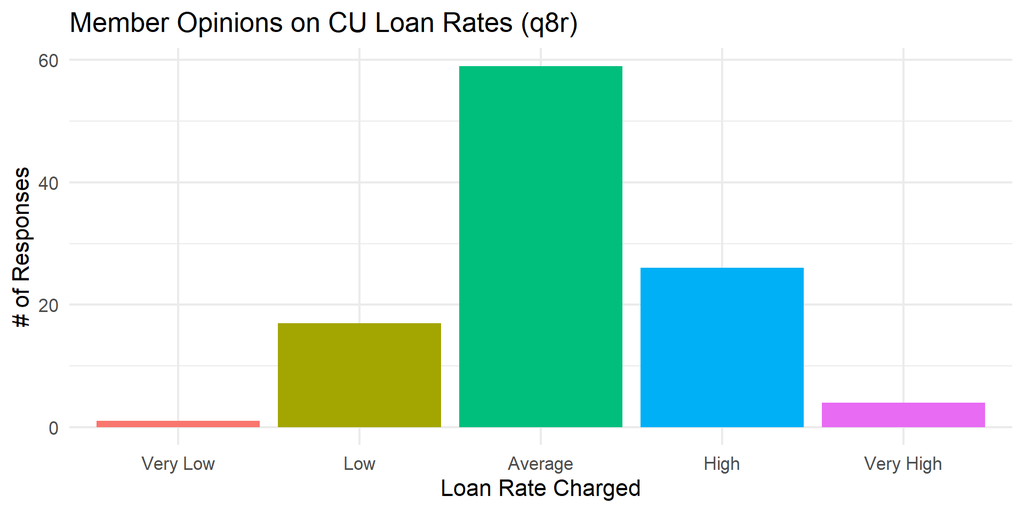

Figure 2: Frequency of Member Opinions on Loan Rates Charged

## Descriptive Statistics: CU Rates Lower (q30)

Table 4: Response Frequency of “CU Loan Rates Are Lower Than Others” (q30)

| Agreement | n | % |
| --- | --- | --- |
| Strongly Disagree | 4 | 3.1 |
| Strongly Agree | 5 | 3.9 |
| Disagree | 27 | 21.1 |
| Uncertain | 59 | 46.1 |
| Agree | 33 | 25.8 |

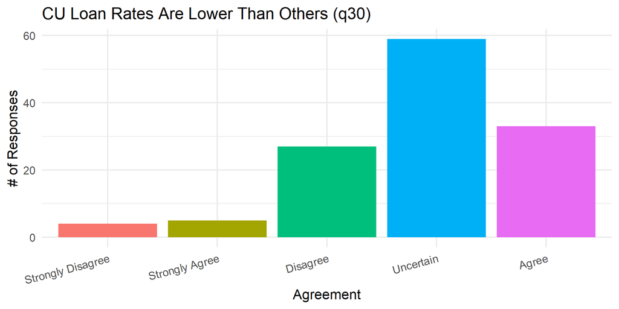

Figure 3: Agreement That CU Loan Rates Are Lower Than Other Institutions

## Descriptive Statistics: Summary

Table 5: Descriptive Statistics for q8r and q30

| Variable | n | mean | sd | median | min | max | skew | kurtosis |
| --- | --- | --- | --- | --- | --- | --- | --- | --- |
| q8r | 107 | 3.14 | 0.76 | 3 | 1 | 5 | 0.15 | 0.17 |
| q30 | 128 | 3.06 | 0.87 | 3 | 1 | 5 | -0.05 | -0.20 |

## One-Sample t-tests

- H<sub>0</sub>: μ = 3 (q8r: “Average”; q30: “Uncertain”)
- H<sub>A</sub>: μ ≠ 3

```r
t.test(case31$q8r, mu = 3)
```

```
    One Sample t-test

data:  case31$q8r
t = 1.9132, df = 106, p-value = 0.05842
alternative hypothesis: true mean is not equal to 3
95 percent confidence interval:
 2.994913 3.285461
sample estimates:
mean of x
 3.140187
```

```r
t.test(case31$q30, mu = 3)
```

```
    One Sample t-test

data:  case31$q30
t = 0.81543, df = 127, p-value = 0.4164
alternative hypothesis: true mean is not equal to 3
95 percent confidence interval:
 2.91083 3.21417
sample estimates:
mean of x
   3.0625
```

One-Sample t-test Results for R2 (test value = 3)

| Variable | n | Mean | SD | t | df | p |
| --- | --- | --- | --- | --- | --- | --- |
| q8r: Loan rates charged | 107 | 3.14 | 0.76 | 1.91 | 106 | 0.0584 |
| q30: CU loan rates lower | 128 | 3.06 | 0.87 | 0.82 | 127 | 0.416 |

**Insights about R2**

- Most members rate the CU’s loan rates as “Average” (55.1%). The mean (*M* = 3.14) is not statistically different from 3 (*p* = 0.0584).
- On whether CU loan rates are lower than other institutions, the most common answer is “Uncertain” (46.1%). The mean (*M* = 3.06) is not statistically different from 3 (*p* = 0.416).
- Members do not see the CU’s loans as cheaper than other lenders. With no rate advantage, members have little reason to borrow from the CU instead of other institutions.

# R5: Chi-square Goodness-of-Fit

**R5: How well are the members aware of the services offered by the credit union?**

- `Constructs and roles`: Awareness of services (descriptive)
- `Operationalization`: q13r-q26r (14 services)
- `Scale`: Ordinal scale (1 = Unaware, 2 = Aware but Have Not Used, 3 = Aware and Have Used)
- `Statistics`: Descriptive statistics (frequency distribution), followed by chi-square goodness-of-fit test

## Frequency Distribution

Table 6: Awareness of Services, % of Members (n = 128)

| Service | Unaware | Aware but Have Not Used | Aware and Have Used |
| --- | --- | --- | --- |
| Regular share accounts | 64.8 | 25.0 | 10.2 |
| Special subaccounts | 35.9 | 54.7 | 9.4 |
| Christmas club accounts | 32.8 | 58.6 | 8.6 |
| Individual retirement accounts | 27.3 | 50.0 | 22.7 |
| MasterCard credit cards | 11.7 | 44.5 | 43.8 |
| Signature loans | 3.9 | 81.2 | 14.8 |
| New car loans | 3.9 | 77.3 | 18.8 |
| Late model car loans | 9.4 | 79.7 | 10.9 |
| Older model car loans | 25.8 | 64.8 | 9.4 |
| Household goods/appliance loans | 28.9 | 62.5 | 8.6 |
| Recreational loans | 43.0 | 46.9 | 10.2 |
| Share collateralized loans | 53.9 | 44.5 | 1.6 |
| IRA loans | 60.9 | 35.9 | 3.1 |
| Line of credit loans | 0.0 | 62.5 | 37.5 |

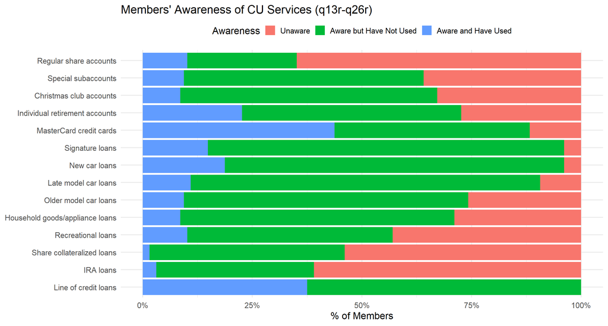

Figure 4: Awareness Levels Across CU Services

## Chi-square Goodness-of-Fit Tests

- H<sub>0</sub>: The awareness levels follow the expected (equal, 1/3 each) distribution
- H<sub>A</sub>: The awareness levels do not follow the expected distribution

```r
# Example: regular share accounts (q13r)
table(as_factor(case31$q13r)) |>
  chisq.test(p = c(1/3, 1/3, 1/3))
```

```
    Chi-squared test for given probabilities

data:  table(as_factor(case31$q13r))
X-squared = 61.422, df = 2, p-value = 4.596e-14
```

Table 7: Chi-square Goodness-of-Fit Tests for All 14 Services (expected = 1/3 per level)

| Variable | Observed | Chi-sq | df | Min. expected | p |
| --- | --- | --- | --- | --- | --- |
| Regular share accounts | Unaware: 83 \| Aware but Have Not Used: 32 \| Aware and Have Used: 13 | 61.42 | 2 | 42.7 | <0.001 |
| Special subaccounts | Unaware: 46 \| Aware but Have Not Used: 70 \| Aware and Have Used: 12 | 39.81 | 2 | 42.7 | <0.001 |
| Christmas club accounts | Unaware: 42 \| Aware but Have Not Used: 75 \| Aware and Have Used: 11 | 48.02 | 2 | 42.7 | <0.001 |
| Individual retirement accounts | Unaware: 35 \| Aware but Have Not Used: 64 \| Aware and Have Used: 29 | 16.42 | 2 | 42.7 | <0.001 |
| MasterCard credit cards | Unaware: 15 \| Aware but Have Not Used: 57 \| Aware and Have Used: 56 | 26.92 | 2 | 42.7 | <0.001 |
| Signature loans | Unaware: 5 \| Aware but Have Not Used: 104 \| Aware and Have Used: 19 | 134.55 | 2 | 42.7 | <0.001 |
| New car loans | Unaware: 5 \| Aware but Have Not Used: 99 \| Aware and Have Used: 24 | 115.80 | 2 | 42.7 | <0.001 |
| Late model car loans | Unaware: 12 \| Aware but Have Not Used: 102 \| Aware and Have Used: 14 | 123.81 | 2 | 42.7 | <0.001 |
| Older model car loans | Unaware: 33 \| Aware but Have Not Used: 83 \| Aware and Have Used: 12 | 62.36 | 2 | 42.7 | <0.001 |
| Household goods/appliance loans | Unaware: 37 \| Aware but Have Not Used: 80 \| Aware and Have Used: 11 | 56.92 | 2 | 42.7 | <0.001 |
| Recreational loans | Unaware: 55 \| Aware but Have Not Used: 60 \| Aware and Have Used: 13 | 31.23 | 2 | 42.7 | <0.001 |
| Share collateralized loans | Unaware: 69 \| Aware but Have Not Used: 57 \| Aware and Have Used: 2 | 59.83 | 2 | 42.7 | <0.001 |
| IRA loans | Unaware: 78 \| Aware but Have Not Used: 46 \| Aware and Have Used: 4 | 64.56 | 2 | 42.7 | <0.001 |
| Line of credit loans | Unaware: 0 \| Aware but Have Not Used: 80 \| Aware and Have Used: 48 | 76.00 | 2 | 42.7 | <0.001 |

**Insights about R5**

- For all 14 services, the awareness levels are significantly different from an equal distribution (all *p* < .001). The expected count is 42.7 in every cell, so the tests are valid.
- For 11 of the 14 services, the most common answer is “Aware but Have Not Used.” Members know about most of the loan products but are not using them (e.g., signature loans: 14.8% have used; new car loans: 18.8%).
- “Unaware” is the most common answer for Regular share accounts, Share collateralized loans, IRA loans.
- Use is low across the board. Only MasterCard credit cards (43.8%) and line of credit loans (37.5%) are used by more than a third of members.
- The CU should raise awareness of its lesser-known services and give members reasons to actually use the loan products they already know about.

# R6: Chi-square & One-Sample t-tests

**R6: What are the members’ attitudes and beliefs about how effectively the credit union is operated?**

- `Constructs and roles`: Attitude toward operational effectiveness (descriptive)
- `Operationalization`:
  - q9_group (statement frequency), q10r (statement accuracy)
  - q11 (statements easy to understand), q12 (account information kept confidential)
  - q31-q34 (confidentiality, loan processing, services meet needs, loan applications)
  - q37r (overall rating of management and operation)
- `Scale`:
  - Ordinal
  - Nominal
  - Interval
  - Interval
- `Statistics`:
  - Descriptive statistics / chi-square goodness-of-fit test
  - Descriptive statistics / chi-square goodness-of-fit test
  - Descriptive statistics / one-sample t-test
  - Descriptive statistics / one-sample t-test

## Statements: Frequency Distributions

Table 8: Statement Frequency (q9_group)

| Statement Frequency | n | % |
| --- | --- | --- |
| Too often | 0 | 0.0 |
| About right | 99 | 77.3 |
| Not often enough | 29 | 22.7 |

Table 9: Statement Accuracy (q10r)

| Statement Accuracy | n | % |
| --- | --- | --- |
| Poor | 2 | 1.6 |
| Fair | 4 | 3.1 |
| Good | 54 | 42.2 |
| Excellent | 68 | 53.1 |

Table 10: Statements Easy to Understand (q11)

| Easy to Understand | n | % |
| --- | --- | --- |
| Yes | 125 | 97.7 |
| No | 3 | 2.3 |

Table 11: CU Keeps Account Information Confidential (q12)

| Confidential | n | % |
| --- | --- | --- |
| Yes | 74 | 69.8 |
| No | 32 | 30.2 |

## Statements: Chi-square Goodness-of-Fit Tests

- H<sub>0</sub>: Responses follow the expected (equal) distribution
- H<sub>A</sub>: Responses do not follow the expected distribution

```r
# Example: statements easy to understand (q11), expected 50% / 50%
table(droplevels(as_factor(case31$q11))) |>
  chisq.test(p = c(.5, .5))
```

```
    Chi-squared test for given probabilities

data:  table(droplevels(as_factor(case31$q11)))
X-squared = 116.28, df = 1, p-value < 2.2e-16
```

Table 12: Chi-square Goodness-of-Fit Tests (expected = equal proportions)

| Variable | Observed | Chi-sq | df | Min. expected | p |
| --- | --- | --- | --- | --- | --- |
| q9_group: Statement frequency | Too often: 0 \| About right: 99 \| Not often enough: 29 | 121.42 | 2 | 42.7 | <0.001 |
| q10r: Statement accuracy | Poor: 2 \| Fair: 4 \| Good: 54 \| Excellent: 68 | 108.25 | 3 | 32.0 | <0.001 |
| q11: Easy to understand | Yes: 125 \| No: 3 | 116.28 | 1 | 64.0 | <0.001 |
| q12: Info kept confidential | Yes: 74 \| No: 32 | 16.64 | 1 | 53.0 | <0.001 |

## Attitudes and Overall Rating: Descriptive Statistics

Table 13: Descriptive Statistics for q31-q34 and q37r

| Variable | n | mean | sd | median | min | max |
| --- | --- | --- | --- | --- | --- | --- |
| q31 | 128 | 3.95 | 0.68 | 4 | 1 | 5 |
| q32 | 128 | 3.72 | 0.79 | 4 | 2 | 5 |
| q33 | 128 | 3.59 | 0.68 | 4 | 2 | 5 |
| q34 | 128 | 3.46 | 0.78 | 4 | 1 | 5 |
| q37r | 121 | 4.07 | 0.73 | 4 | 1 | 5 |

q31-q34: 1 = Strongly Disagree … 5 = Strongly Agree. q37r: 1 = Very Poor … 5 = Excellent. q31-q34 are tested as separate items because their reliability in IC10-2-1 was too low to combine them into an index.

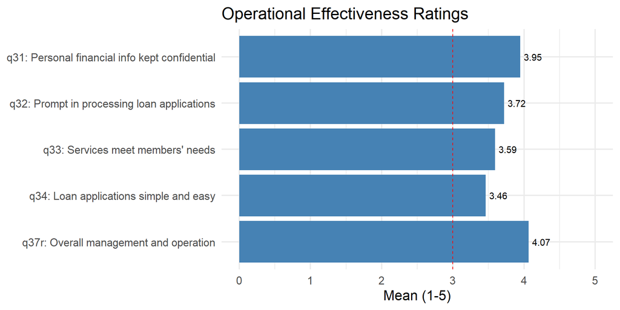

Figure 5: Mean Ratings of Operational Effectiveness (midpoint = 3)

## One-Sample t-tests

- H<sub>0</sub>: μ = 3 (q31-q34: “Uncertain”; q37r: “Average”)
- H<sub>A</sub>: μ ≠ 3

```r
# Example: overall rating of management and operation (q37r)
t.test(case31$q37r, mu = 3)
```

```
    One Sample t-test

data:  case31$q37r
t = 16.125, df = 120, p-value < 2.2e-16
alternative hypothesis: true mean is not equal to 3
95 percent confidence interval:
 3.935211 4.197020
sample estimates:
mean of x
 4.066116
```

Table 14: One-Sample t-test Results for R6 (test value = 3)

| Variable | n | Mean | SD | t | df | p |
| --- | --- | --- | --- | --- | --- | --- |
| q31: Personal financial info kept confidential | 128 | 3.95 | 0.68 | 15.74 | 127 | <0.001 |
| q32: Prompt in processing loan applications | 128 | 3.72 | 0.79 | 10.25 | 127 | <0.001 |
| q33: Services meet members’ needs | 128 | 3.59 | 0.68 | 9.87 | 127 | <0.001 |
| q34: Loan applications simple and easy | 128 | 3.46 | 0.78 | 6.66 | 127 | <0.001 |
| q37r: Overall management and operation | 121 | 4.07 | 0.73 | 16.12 | 120 | <0.001 |

**Insights about R6**

- **Statements:** Most members say statement frequency is “About right” (77.3%), and no one says “Too often.” Most rate accuracy as “Good” or “Excellent” (95.3%), and almost all find statements easy to understand (97.7%). All four distributions differ significantly from equal proportions (*p* < .001).
- **Confidentiality:** 69.8% say the CU keeps account information confidential (q12, *p* < .001), and q31 has the highest agreement of the four attitude items (*M* = 3.95).
- **Loan processing and services:** Members agree, but less strongly, that loan applications are processed promptly (*M* = 3.72), services meet their needs (*M* = 3.59), and loan applications are simple and easy (*M* = 3.46). All are significantly above 3 (*p* < .001), but loan applications have the lowest score.
- **Overall:** Members rate the CU’s management and operation as good (*M* = 4.07, *p* < .001).
- Members believe the CU is run effectively. Loan applications score lowest, so making them simpler could help the CU’s borrowing problem.

# Appendix

## Links

- [GitHub Pages: this presentation](https://jakevns.github.io/IBM6500/IC11-2-Case-31-Summary-Analysis/Evans_Jake-IC11-2-Case31-Summary-R1-R2-R5-R6.html)
- [GitHub Repo: IC11-2 folder](https://github.com/jakevns/IBM6500/tree/main/IC11-2-Case-31-Summary-Analysis)